# Uncertainty Quantification via Conformal Prediction

Biostat 274

Author

Dr. Jin Zhou @ UCLA

Published

March 9, 2026

Credit: This note draws from

- Angelopoulos & Bates (2023). [*A Gentle Introduction to Conformal Prediction and Distribution-Free Uncertainty Quantification*](https://arxiv.org/abs/2107.07511). *Foundations and Trends in Machine Learning*, 16(4), 494–591.
- Tibshirani (2024). [*Conformal Prediction*](https://www.stat.berkeley.edu/~ryantibs/statlearn-s24/lectures/conformal.pdf). Lecture notes, Advanced Topics in Statistical Learning, UC Berkeley.
- Tibshirani, Barber, Candès, Ramdas (2019). [*Conformal Prediction Under Covariate Shift*](https://www.stat.cmu.edu/~ryantibs/papers/weightedcp.pdf). *NeurIPS 2019*.

## 1 Motivation: From Calibration to Per-Prediction Uncertainty

### 1.1 Recap: What Calibration Tells Us

In the previous lecture, we studied **calibration**: does a predicted probability $\hat{p}$ match the observed event rate?

We learned to measure this (Brier score, calibration slope/intercept, ICI), diagnose the type of shift (label, covariate, concept), and fix it via recalibration (intercept-only, Platt scaling, isotonic regression).

Calibration answers: **“Among all patients with $\hat{p} \approx 0.3$, is the event rate roughly 30%?”**

This is an **aggregate** property — it says nothing about **any individual patient**.

### 1.2 What Calibration Cannot Tell Us

Consider two patients from our readmission project:

- Patient A: Medicare, age 72, $\hat{p} = 0.22$
- Patient B: Medicare, age 68, $\hat{p} = 0.36$

A clinician asks: *“For Patient A specifically, how confident are you in this 22% estimate?”*

Calibration cannot answer this. Even a perfectly calibrated model gives no individual-level reliability guarantee.

### 1.3 The Question This Lecture Answers

> **Conformal prediction asks:** Can we construct a **set** of plausible outcomes such that, for a new observation drawn from the same population, the true outcome falls in the set with probability $\geq 1 - \alpha$?

| Already taught | This lecture |
| --- | --- |
| Calibration: $P(Y{=}1 \mid \hat{p} \approx 0.3) \approx 0.3$ | Conformal: $P(Y_{\text{new}} \in C(X_{\text{new}})) \geq 1 - \alpha$ |
| Fixes **aggregate** probabilities | Gives **prediction sets** with marginal coverage guarantee |
| Calibration diagnostics are nonparametric; some recalibration methods assume a logistic link | **Distribution-free**, model-agnostic |
| Recalibration: asymptotic justification | **Finite-sample** guarantee |

Calibration and conformal prediction are **complementary**, not competing. Calibration makes predicted probabilities trustworthy; conformal prediction wraps any prediction in a set with a formal coverage guarantee. They answer different questions.

## 2 The Key Idea: Ranks and Exchangeability

### 2.1 Intuition Without Features

Before diving into the full algorithm, let’s build intuition with a toy example that has **no features** — just a sequence of numbers.

Suppose we observe $Y_1, Y_2, \ldots, Y_n$ drawn i.i.d. from some unknown distribution $P$. We want to find a value $\hat{q}$ such that

$$P(Y_{n+1} \leq \hat{q}) \geq 1 - \alpha.$$

**Naive approach:** set $\hat{q}$ to the $(1-\alpha)$ sample quantile of $Y_1, \ldots, Y_n$. This works approximately, but only as $n \to \infty$.

**Conformal insight:** Because $Y_{n+1}$ is exchangeable with $Y_1, \ldots, Y_n$, the rank of $Y_{n+1}$ among all $n+1$ values is **uniformly distributed**. Therefore:

$$P\Big(Y_{n+1} \leq \text{the } \lceil(1-\alpha)(n+1)\rceil\text{-th smallest of } Y_1, \ldots, Y_n\Big) \geq 1 - \alpha.$$

This is **exact** — no asymptotics, no distributional assumptions. The only requirement is **exchangeability**.

### 2.2 Exchangeability

**NoteWhat is exchangeability?**

Random variables $Z_1, \ldots, Z_{n+1}$ are **exchangeable** if their joint distribution is invariant under permutations:
$$(Z_1, \ldots, Z_{n+1}) \overset{d}{=} (Z_{\sigma(1)}, \ldots, Z_{\sigma(n+1)}) \quad \text{for all permutations } \sigma.$$
i.i.d. data are exchangeable, but exchangeability is **weaker** — it does not require independence.

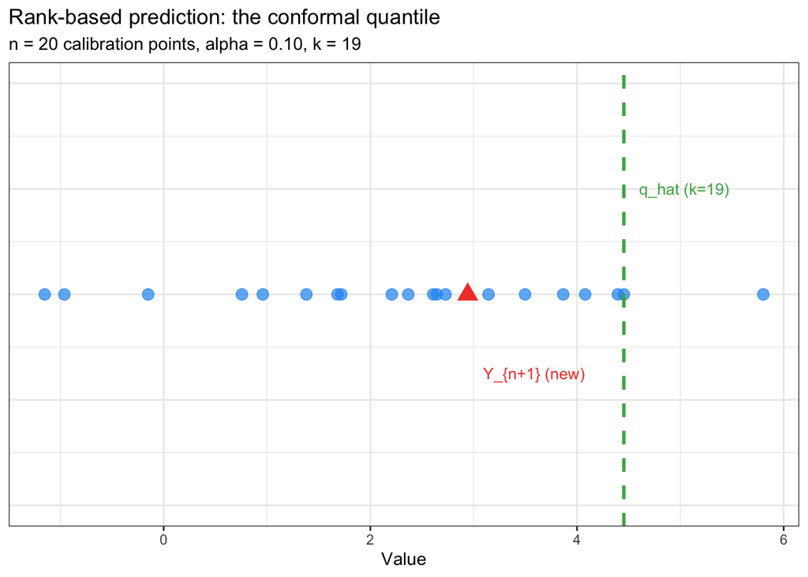

Figure 1: The rank of Y_{n+1} is uniform among n+1 values. Setting the quantile at the ⌈(1-α)(n+1)⌉-th order statistic guarantees at least 1-α coverage.

```r
library(tidyverse)
library(patchwork)

set.seed(274)
n <- 20
alpha <- 0.10

Y <- rnorm(n + 1, mean = 3, sd = 1.5)
Y_cal <- Y[1:n]
Y_new <- Y[n + 1]

k <- ceiling((1 - alpha) * (n + 1))
q_hat <- sort(Y_cal)[min(k, n)]

tibble(value = Y_cal, idx = seq_len(n)) %>%
  ggplot(aes(x = value, y = 0)) +
  geom_point(size = 3, color = "#2196F3", alpha = 0.7) +
  geom_point(aes(x = Y_new), color = "#F44336", size = 4, shape = 17) +
  geom_vline(xintercept = q_hat, linetype = "dashed", color = "#4CAF50", linewidth = 1) +
  annotate("text", x = q_hat + 0.15, y = 0.02,
           label = paste0("q_hat (k=", k, ")"), color = "#4CAF50", hjust = 0, size = 3.5) +
  annotate("text", x = Y_new + 0.15, y = -0.015,
           label = "Y_{n+1} (new)", color = "#F44336", hjust = 0, size = 3.5) +
  scale_y_continuous(limits = c(-0.04, 0.04)) +
  labs(x = "Value", y = NULL,
       title = "Rank-based prediction: the conformal quantile",
       subtitle = sprintf("n = %d calibration points, alpha = %.2f, k = %d", n, alpha, k)) +
  theme_bw() +
  theme(axis.text.y = element_blank(), axis.ticks.y = element_blank())
```

### 2.3 The Finite-Sample Coverage Bound

With the conformal quantile $\hat{q}$ defined above:

$$1 - \alpha \;\leq\; P(Y_{n+1} \leq \hat{q}) \;\leq\; 1 - \alpha + \frac{1}{n+1}$$

- The **lower bound** always holds (the guarantee).
- The **upper bound** holds when ties are almost surely absent.
- As $n \to \infty$, coverage converges to exactly $1 - \alpha$.

> **Key insight:** The only requirement is that the calibration data and the test point are **exchangeable**. No assumptions about the distribution, no model correctness, no asymptotics.

## 3 Split Conformal Prediction for Regression

### 3.1 The Overfitting Problem

Why can’t we simply compute residuals on the **training set** and use them to build prediction intervals?

Because the model $\hat{f}$ was **trained on** $(X_i, Y_i)$ for $i$ in the training set. The training residuals $|Y_i - \hat{f}(X_i)|$ are systematically **too small** — the model has already seen these points. A new test residual $|Y_{n+1} - \hat{f}(X_{n+1})|$ will typically be **larger**, so prediction intervals based on training residuals will **undercover**.

**Solution:** hold out a separate **calibration set** that the model never saw.

### 3.2 The Algorithm: Split Conformal Prediction

**Data splitting:**

1. **Proper training set** $D_1$: fit the model $\hat{f}$.
2. **Calibration set** $D_2 = \{(X_i, Y_i)\}_{i=1}^{n_2}$: compute scores (model never saw these).
3. **Test point** $(X_{n+1}, Y_{n+1})$: construct prediction set.

**Three steps:**

1. Compute **nonconformity scores** (residuals) on $D_2$:
   $$R_i = |Y_i - \hat{f}(X_i)|, \quad i \in D_2$$
2. Compute the **conformal quantile** (the $k$-th order statistic, where $k = \min(\lceil(1-\alpha)(n_2+1)\rceil, n_2)$):
   $$\hat{q} = R_{(k)}$$
3. Form the **prediction interval** for a new test point:
   $$C(X_{n+1}) = \Big[\hat{f}(X_{n+1}) - \hat{q},\;\; \hat{f}(X_{n+1}) + \hat{q}\Big]$$

**WarningImplementation detail: use order statistics, not interpolated quantiles**

The conformal quantile must be the $k$-th smallest score. In R, use `sort(scores)[k]`, **not** `quantile(scores, ...)`. The base R `quantile()` function uses interpolation by default (Type 7), which can violate the exact finite-sample guarantee.

### 3.3 Coverage Guarantee

**NoteTheorem (Vovk et al., 2005; Lei et al., 2018)**

If $(X_i, Y_i)_{i \in D_2}$ and $(X_{n+1}, Y_{n+1})$ are exchangeable (conditional on the proper training set $D_1$), then
$$P\Big(Y_{n+1} \in C(X_{n+1}) \;\Big|\; D_1\Big) \;\in\; \Big[1 - \alpha,\;\; 1 - \alpha + \frac{1}{n_2 + 1}\Big).$$
This holds for **any** model $\hat{f}$, **any** distribution $P$, and **any** finite sample size $n_2$.

### 3.4 Demo: Conformal Intervals for Regression

```r
set.seed(274)

n_total <- 600
x_all   <- runif(n_total, 0, 5)
y_all   <- sin(2 * x_all) + 0.5 * x_all + rnorm(n_total, sd = 0.3 + 0.2 * x_all)

idx       <- sample(n_total)
train_idx <- idx[1:300]
cal_idx   <- idx[301:450]
test_idx  <- idx[451:600]

x_train <- x_all[train_idx]; y_train <- y_all[train_idx]
x_cal   <- x_all[cal_idx];   y_cal   <- y_all[cal_idx]
x_test  <- x_all[test_idx];  y_test  <- y_all[test_idx]

library(randomForest)
rf_fit <- randomForest(y_train ~ ., data = data.frame(x = x_train, y_train = y_train))
```

```r
# Step 1: Nonconformity scores on calibration set
yhat_cal   <- predict(rf_fit, newdata = data.frame(x = x_cal))
scores_reg <- abs(y_cal - yhat_cal)

# Step 2: Conformal quantile (order statistic, NOT interpolated)
alpha <- 0.10
n_cal <- length(scores_reg)
k     <- min(ceiling((1 - alpha) * (n_cal + 1)), n_cal)
q_hat <- sort(scores_reg)[k]

cat(sprintf("Calibration set size: n2 = %d\n", n_cal))
```

```
Calibration set size: n2 = 150
```

```r
cat(sprintf("k = min(ceil((1-%.2f)*(%d+1)), %d) = %d\n", alpha, n_cal, n_cal, k))
```

```
k = min(ceil((1-0.10)*(150+1)), 150) = 136
```

```r
cat(sprintf("Conformal quantile q_hat = %.3f  (k-th order statistic)\n", q_hat))
```

```
Conformal quantile q_hat = 1.725  (k-th order statistic)
```

```r
# Step 3: Prediction intervals on test set
yhat_test <- predict(rf_fit, newdata = data.frame(x = x_test))
lower     <- yhat_test - q_hat
upper     <- yhat_test + q_hat

coverage <- mean(y_test >= lower & y_test <= upper)
cat(sprintf("Empirical coverage on test set: %.3f  (target: >= %.2f)\n", coverage, 1 - alpha))
```

```
Empirical coverage on test set: 0.947  (target: >= 0.90)
```

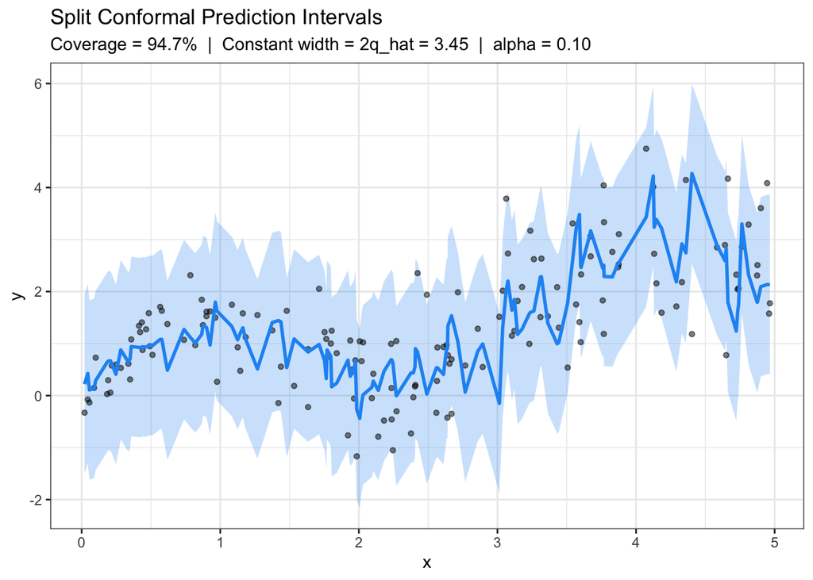

Figure 2: Split conformal prediction intervals (blue band) around a random forest fit. The interval has constant width – it does not adapt to local uncertainty.

```r
ord <- order(x_test)
tibble(x = x_test[ord], y = y_test[ord],
       yhat = yhat_test[ord], lo = lower[ord], hi = upper[ord]) %>%
  ggplot(aes(x = x)) +
  geom_ribbon(aes(ymin = lo, ymax = hi), fill = "#2196F3", alpha = 0.25) +
  geom_point(aes(y = y), size = 1.2, alpha = 0.5) +
  geom_line(aes(y = yhat), color = "#2196F3", linewidth = 1) +
  labs(x = "x", y = "y",
       title = "Split Conformal Prediction Intervals",
       subtitle = sprintf("Coverage = %.1f%%  |  Constant width = 2q_hat = %.2f  |  alpha = %.2f",
                          100 * coverage, 2 * q_hat, alpha)) +
  theme_bw()
```

### 3.5 Adaptive-Width Intervals

The basic split conformal interval has **constant width** $2\hat{q}$ everywhere. This is wasteful: in easy regions the interval is too wide, and in hard regions it may be too narrow **locally** (even though marginal coverage is maintained).

**Fix: Normalized (studentized) residuals.** Fit a second model $\hat{\sigma}(x)$ to predict the spread of $|Y - \hat{f}(X)|$, then use the score $R_i = |Y_i - \hat{f}(X_i)| / \hat{\sigma}(X_i)$.

This gives **adaptive-width** intervals: $C(x) = [\hat{f}(x) - \hat{q}\hat{\sigma}(x),\;\hat{f}(x) + \hat{q}\hat{\sigma}(x)]$. The coverage guarantee still holds — only the score function changed.

```r
res_train <- abs(y_train - predict(rf_fit, newdata = data.frame(x = x_train)))
sigma_fit <- randomForest(res_train ~ ., data = data.frame(x = x_train, res_train = res_train))

sigma_cal  <- pmax(predict(sigma_fit, newdata = data.frame(x = x_cal)), 0.01)
sigma_test <- pmax(predict(sigma_fit, newdata = data.frame(x = x_test)), 0.01)

scores_norm <- abs(y_cal - yhat_cal) / sigma_cal
q_hat_norm  <- sort(scores_norm)[k]

lower_norm <- yhat_test - q_hat_norm * sigma_test
upper_norm <- yhat_test + q_hat_norm * sigma_test
cov_norm   <- mean(y_test >= lower_norm & y_test <= upper_norm)
cat(sprintf("Adaptive coverage: %.3f\n", cov_norm))
```

```
Adaptive coverage: 0.893
```

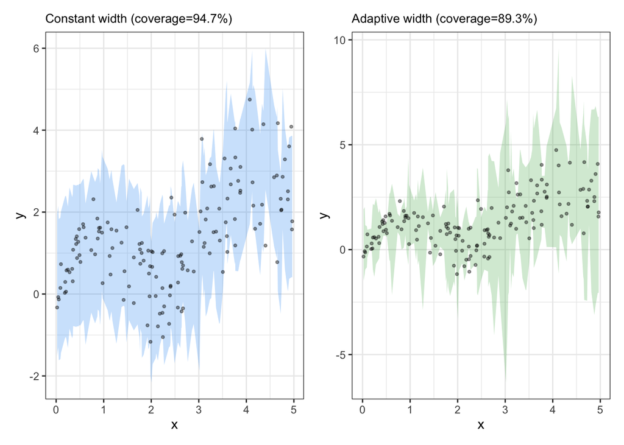

Figure 3: Constant-width (left) vs. adaptive-width (right) conformal intervals. The adaptive version widens where uncertainty is higher (larger x).

```r
ord <- order(x_test)
p1 <- tibble(x = x_test[ord], y = y_test[ord], lo = lower[ord], hi = upper[ord]) %>%
  ggplot(aes(x = x)) +
  geom_ribbon(aes(ymin = lo, ymax = hi), fill = "#2196F3", alpha = 0.25) +
  geom_point(aes(y = y), size = 0.8, alpha = 0.4) +
  labs(title = sprintf("Constant width (coverage=%.1f%%)", 100 * coverage), y = "y") +
  theme_bw() + theme(plot.title = element_text(size = 10))

p2 <- tibble(x = x_test[ord], y = y_test[ord], lo = lower_norm[ord], hi = upper_norm[ord]) %>%
  ggplot(aes(x = x)) +
  geom_ribbon(aes(ymin = lo, ymax = hi), fill = "#4CAF50", alpha = 0.25) +
  geom_point(aes(y = y), size = 0.8, alpha = 0.4) +
  labs(title = sprintf("Adaptive width (coverage=%.1f%%)", 100 * cov_norm), y = "y") +
  theme_bw() + theme(plot.title = element_text(size = 10))

p1 + p2
```

## 4 Split Conformal Prediction for Classification

Classification is where conformal prediction connects most directly to the final project. The idea is the same — we just change the **score function**.

### 4.1 Score Function for Classification

Given a classifier $\hat{f}(x)$ that outputs estimated class probabilities $\hat{f}(x)_y$ for each class $y$, the simplest nonconformity score is:

$$s_i = 1 - \hat{f}(X_i)_{Y_i}$$

This is **one minus the predicted probability of the true class**. The score is high when the model assigns low probability to the correct answer.

### 4.2 The Algorithm

1. **Compute scores** on calibration set: $s_i = 1 - \hat{f}(X_i)_{Y_i}$ for $i = 1, \ldots, n_2$
2. **Conformal quantile**: $k = \min\big(\lceil(1-\alpha)(n_2+1)\rceil,\; n_2\big)$, then $\hat{q} = s_{(k)}$
3. **Prediction set** for a new $X_{n+1}$:
   $$C(X_{n+1}) = \big\{y : \hat{f}(X_{n+1})_y \geq 1 - \hat{q}\big\}$$

   Include every class whose predicted probability exceeds the threshold $1 - \hat{q}$.

### 4.3 Interpretation for Binary Classification

For a binary outcome (e.g., readmitted: Yes/No), the prediction set $C(x)$ can take several forms:

| Set | Meaning | Clinical interpretation |
| --- | --- | --- |
| $C(x) = \{\text{Yes}\}$ or $\{\text{No}\}$ | One class is plausible | Model is **confident** about this patient |
| $C(x) = \{\text{Yes}, \text{No}\}$ | Both classes are plausible | Model is **uncertain** — consider flagging for review |
| $C(x) = \emptyset$ | Neither class passes threshold | **Abstention**: insufficient confidence at this $\alpha$ |

**NoteEmpty sets and non-singleton sets in binary classification**

Whether you observe empty sets ($|C|=0$) or two-element sets ($|C|=2$) depends on the threshold $1-\hat{q}$ relative to 0.5. If $1-\hat{q} > 0.5$, then for some patients neither class passes the threshold and the set is empty (abstention). If $1-\hat{q} \leq 0.5$, at least one class always passes, and uncertain cases show as $|C|=2$. Both are valid — they represent different regimes of the same guarantee.

### 4.4 Demo: Conformal Prediction Sets for Classification

```r
set.seed(274)

n_total <- 2000
x1 <- rnorm(n_total); x2 <- rnorm(n_total); x3 <- rbinom(n_total, 1, 0.4)
log_odds <- -1.5 + 0.7 * x1 + 0.5 * x2 + 0.4 * x3
true_prob <- plogis(log_odds)
y <- factor(rbinom(n_total, 1, true_prob), levels = c(0, 1), labels = c("No", "Yes"))

df <- tibble(y, x1, x2, x3)

idx <- sample(n_total)
df_train <- df[idx[1:1000], ]
df_cal   <- df[idx[1001:1400], ]
df_test  <- df[idx[1401:2000], ]

lr_fit <- glm(y ~ x1 + x2 + x3, data = df_train, family = binomial)

p_cal  <- predict(lr_fit, newdata = df_cal,  type = "response")
p_test <- predict(lr_fit, newdata = df_test, type = "response")
y_cal  <- df_cal$y
y_test <- df_test$y
```

```r
# Step 1: Nonconformity scores
s_cal <- ifelse(y_cal == "Yes", 1 - p_cal, p_cal)

cat("Step 1: Nonconformity scores (first 10):\n")
```

```
Step 1: Nonconformity scores (first 10):
```

```r
cat(sprintf("  Patient %d: true = %s, p(Yes) = %.3f, score = %.3f\n",
            1:10, y_cal[1:10], p_cal[1:10], s_cal[1:10]))
```

```
  Patient 1: true = No, p(Yes) = 0.247, score = 0.247
   Patient 2: true = No, p(Yes) = 0.095, score = 0.095
   Patient 3: true = No, p(Yes) = 0.102, score = 0.102
   Patient 4: true = No, p(Yes) = 0.259, score = 0.259
   Patient 5: true = No, p(Yes) = 0.188, score = 0.188
   Patient 6: true = Yes, p(Yes) = 0.395, score = 0.605
   Patient 7: true = No, p(Yes) = 0.221, score = 0.221
   Patient 8: true = Yes, p(Yes) = 0.098, score = 0.902
   Patient 9: true = No, p(Yes) = 0.246, score = 0.246
   Patient 10: true = No, p(Yes) = 0.371, score = 0.371
```

```r
# Step 2: Conformal quantile (order statistic)
alpha <- 0.10
n_cal <- length(s_cal)
k     <- min(ceiling((1 - alpha) * (n_cal + 1)), n_cal)
q_hat <- sort(s_cal)[k]

cat(sprintf("\nStep 2: k = %d, q_hat = s_(%d) = %.4f\n", k, k, q_hat))
```

```
Step 2: k = 361, q_hat = s_(361) = 0.7295
```

```r
cat(sprintf("  Threshold for inclusion: 1 - q_hat = %.4f\n", 1 - q_hat))
```

```
  Threshold for inclusion: 1 - q_hat = 0.2705
```

```r
# Step 3: Prediction sets
make_pred_set <- function(p, q_hat) {
  S <- c()
  if (p >= 1 - q_hat) S <- c(S, "Yes")
  if ((1 - p) >= 1 - q_hat) S <- c(S, "No")
  S
}

pred_sets <- lapply(p_test, make_pred_set, q_hat = q_hat)

cat(sprintf("\nStep 3: Example prediction sets (first 10):\n"))
```

```
Step 3: Example prediction sets (first 10):
```

```r
for (i in 1:10) {
  set_str <- if (length(pred_sets[[i]]) == 0) "empty" else paste(pred_sets[[i]], collapse = ", ")

cat(sprintf("  Patient %d: p(Yes) = %.3f -> C(x) = { %s }  (true: %s) %s\n",
              i, p_test[i], set_str, y_test[i],
              ifelse(as.character(y_test[i]) %in% pred_sets[[i]], "ok", "miss")))

}
```

```
  Patient 1: p(Yes) = 0.035 -> C(x) = { No }  (true: Yes) miss
  Patient 2: p(Yes) = 0.394 -> C(x) = { Yes, No }  (true: No) ok
  Patient 3: p(Yes) = 0.161 -> C(x) = { No }  (true: Yes) miss
  Patient 4: p(Yes) = 0.250 -> C(x) = { No }  (true: No) ok
  Patient 5: p(Yes) = 0.338 -> C(x) = { Yes, No }  (true: No) ok
  Patient 6: p(Yes) = 0.326 -> C(x) = { Yes, No }  (true: No) ok
  Patient 7: p(Yes) = 0.196 -> C(x) = { No }  (true: No) ok
  Patient 8: p(Yes) = 0.057 -> C(x) = { No }  (true: No) ok
  Patient 9: p(Yes) = 0.103 -> C(x) = { No }  (true: No) ok
  Patient 10: p(Yes) = 0.205 -> C(x) = { No }  (true: No) ok
```

```r
coverage  <- mean(mapply(function(S, y) as.character(y) %in% S, pred_sets, y_test))
set_sizes <- sapply(pred_sets, length)

cat(sprintf("Empirical coverage: %.3f  (target: >= %.2f)\n", coverage, 1 - alpha))
```

```
Empirical coverage: 0.885  (target: >= 0.90)
```

```r
cat(sprintf("Set sizes: |C|=0: %d  |C|=1: %d  |C|=2: %d\n",
            sum(set_sizes == 0), sum(set_sizes == 1), sum(set_sizes == 2)))
```

```
Set sizes: |C|=0: 0  |C|=1: 399  |C|=2: 201
```

```r
cat(sprintf("Average set size: %.3f\n", mean(set_sizes)))
```

```
Average set size: 1.335
```

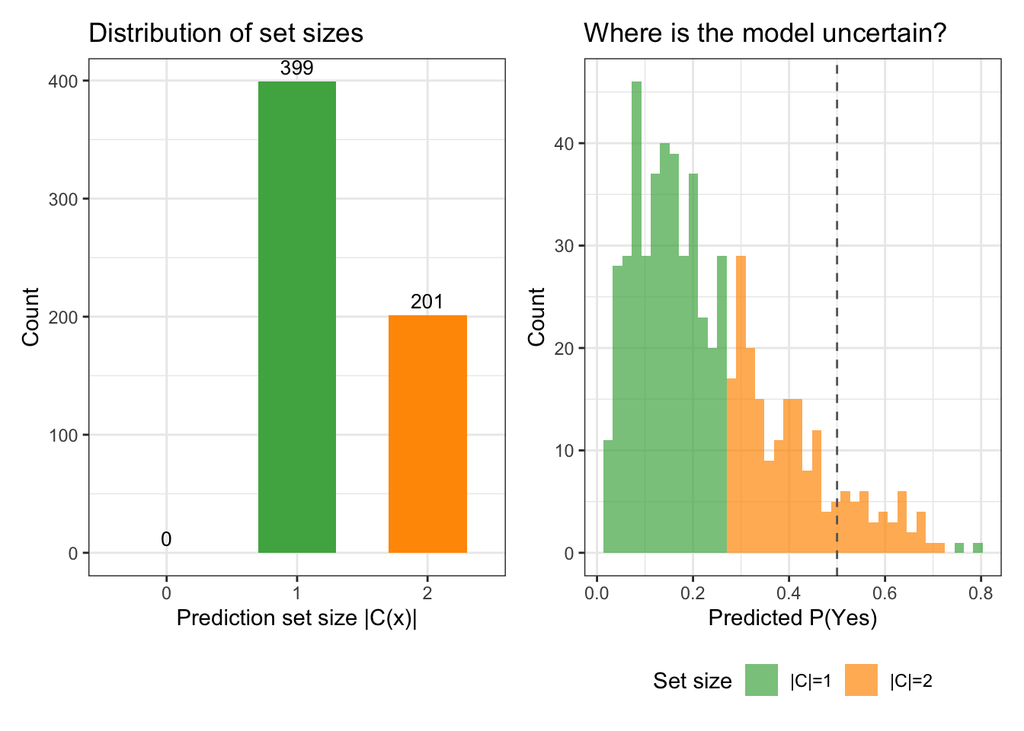

Figure 4: Left: Distribution of prediction set sizes. Right: Patients with non-singleton sets cluster near p_hat near 0.5.

```r
p1 <- tibble(set_size = factor(set_sizes, levels = 0:2)) %>%
  count(set_size, .drop = FALSE) %>%
  ggplot(aes(x = set_size, y = n, fill = set_size)) +
  geom_col(width = 0.6) +
  geom_text(aes(label = n), vjust = -0.5, size = 3.5) +
  scale_fill_manual(values = c("0" = "#F44336", "1" = "#4CAF50", "2" = "#FF9800")) +
  labs(x = "Prediction set size |C(x)|", y = "Count",
       title = "Distribution of set sizes") +
  theme_bw() + theme(legend.position = "none")

p2 <- tibble(p_hat = p_test, set_size = factor(set_sizes)) %>%
  ggplot(aes(x = p_hat, fill = set_size)) +
  geom_histogram(bins = 40, alpha = 0.7, position = "stack") +

  scale_fill_manual(values = c("1" = "#4CAF50", "2" = "#FF9800"),
                    labels = c("|C|=1", "|C|=2")) +
  geom_vline(xintercept = 0.5, linetype = "dashed", color = "gray40") +
  labs(x = "Predicted P(Yes)", y = "Count", fill = "Set size",
       title = "Where is the model uncertain?") +
  theme_bw() + theme(legend.position = "bottom")

p1 + p2
```

> **Key observation:** Patients with non-singleton prediction sets cluster near $\hat{p} \approx 0.5$ — exactly where the model has the least discriminative power. Conformal prediction automatically identifies these hard cases.

## 5 Why Does This Work? The Proof

We give the proof for split conformal prediction, following Tibshirani (2024). It is surprisingly short.

**Setting:** We have fitted $\hat{f}$ on $D_1$ (proper training set). Conditional on $D_1$, the calibration scores $R_i = V(X_i, Y_i)$ for $i \in D_2$ and the test score $R_{n+1} = V(X_{n+1}, Y_{n+1})$ are **exchangeable** (and i.i.d. if the original data are i.i.d.), because $\hat{f}$ is fixed and the calibration and test data are drawn from the same distribution.

**Proof.** Since $R_1, \ldots, R_{n_2}, R_{n+1}$ are exchangeable, the rank of $R_{n+1}$ among all $n_2 + 1$ values is uniform over $\{1, \ldots, n_2 + 1\}$. Therefore:

$$P\Big(R_{n+1} \leq \hat{q}\Big) = P\Big(\text{rank of } R_{n+1} \leq \lceil(1-\alpha)(n_2+1)\rceil\Big) = \frac{\lceil(1-\alpha)(n_2+1)\rceil}{n_2+1} \geq 1 - \alpha. \quad \blacksquare$$

The entire proof rests on one fact: **the rank of an exchangeable random variable among its peers is uniform**.

**NoteThe guarantee depends on the data, not the model**

The coverage guarantee holds for **any** model — good or bad, calibrated or not. A bad model produces large, spread-out scores, so $\hat{q}$ is large, so more outcomes are included — valid but uninformative coverage. A good model produces concentrated scores, so $\hat{q}$ is smaller and prediction sets are tighter. The guarantee breaks only when the **data** violate exchangeability (e.g., distribution shift between calibration and test), not when the model is poor.

### 5.1 What the Guarantee Does and Does Not Say

| It guarantees | It does not guarantee |
| --- | --- |
| **Marginal** coverage: $P(Y_{\text{new}} \in C(X_{\text{new}})) \geq 1-\alpha$, averaged over the randomness in both the calibration set and the new test point | **Conditional** coverage: $P(Y \in C(X) \mid X = x) \geq 1-\alpha$ for every fixed $x$ (impossible distribution-free) |
| **Finite-sample** validity: works for any $n_2$ | Small or informative sets — a bad model gives large, uninformative sets |
| **Distribution-free**: no assumptions on $P(X, Y)$ | Validity under **non-exchangeable** data (e.g., distribution shift) |

**NoteMarginal vs. conditional coverage**

Conformal prediction guarantees **marginal** coverage — averaged over all possible test points. It does **not** guarantee that every subgroup has $1-\alpha$ coverage. In clinical terms: among all patients drawn from the same population, 90% will have the true label in their prediction set, but this might not hold separately for every age group or diagnosis category. Extensions like **group-balanced conformal prediction** address this, but require larger calibration sets per group.

## 6 Effect of Calibration Set Size

The coverage guarantee holds for **any** $n_2$, but the **tightness** depends on $n_2$:

- Coverage is between $1-\alpha$ and $1 - \alpha + \frac{1}{n_2+1}$
- With $n_2 = 100$: coverage is between $0.900$ and $0.910$
- With $n_2 = 1000$: coverage is between $0.900$ and $0.901$

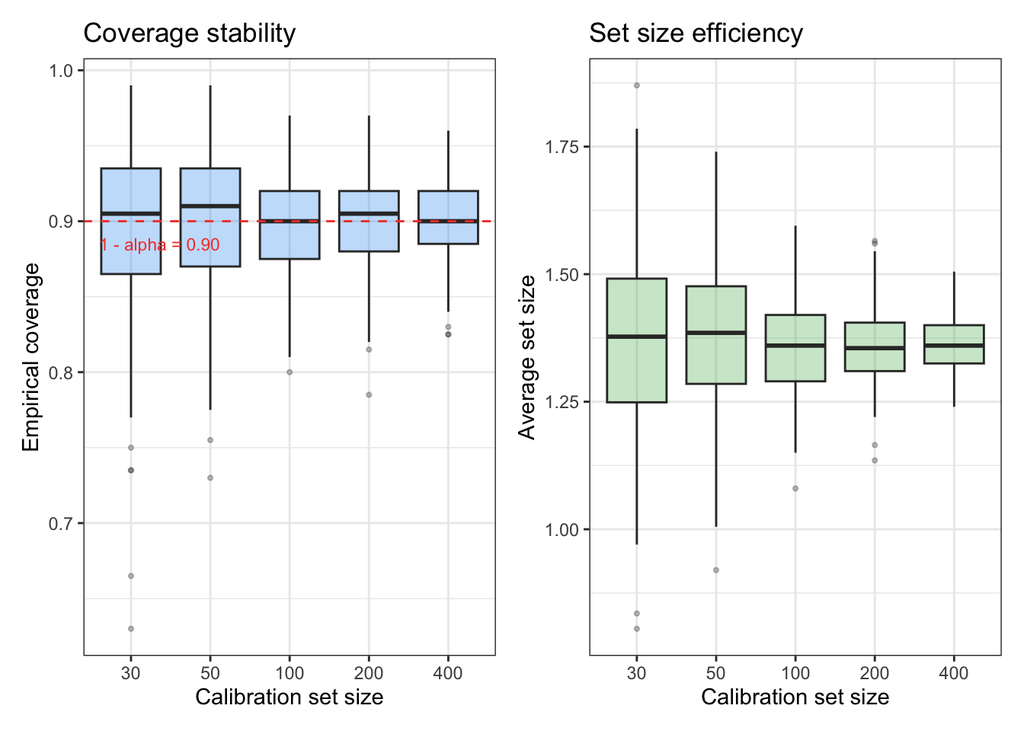

Figure 5: Left: With more calibration data, empirical coverage hugs the target more tightly. Right: Average set size stabilizes as the calibration set grows.

```r
set.seed(274)
cal_sizes <- c(30, 50, 100, 200, 400)
n_rep <- 200
alpha <- 0.10

results <- expand_grid(n_cal = cal_sizes, rep = 1:n_rep) %>%
  rowwise() %>%
  mutate(
    sim = list({
      pool <- sample(nrow(df_test) + nrow(df_cal))
      idx_c <- pool[1:n_cal]
      idx_t <- pool[(n_cal+1):min(n_cal+200, length(pool))]

      p_all <- c(p_cal, p_test)
      y_all <- c(as.character(y_cal), as.character(y_test))

      sc <- ifelse(y_all[idx_c] == "Yes", 1 - p_all[idx_c], p_all[idx_c])
      kk <- min(ceiling((1 - alpha) * (length(sc) + 1)), length(sc))
      qh <- sort(sc)[kk]

      ps <- lapply(p_all[idx_t], function(p) {
        S <- c()
        if (p >= 1 - qh) S <- c(S, "Yes")
        if ((1 - p) >= 1 - qh) S <- c(S, "No")
        S
      })

      cov <- mean(mapply(function(S, y) y %in% S, ps, y_all[idx_t]))
      sz  <- mean(sapply(ps, length))
      list(cov = cov, sz = sz)
    })
  ) %>%
  unnest_wider(sim)

p1 <- results %>%
  ggplot(aes(x = factor(n_cal), y = cov)) +
  geom_boxplot(fill = "#2196F3", alpha = 0.3, outlier.size = 0.8) +
  geom_hline(yintercept = 1 - alpha, linetype = "dashed", color = "#F44336") +
  annotate("text", x = 0.6, y = 1 - alpha - 0.015, label = "1 - alpha = 0.90",
           color = "#F44336", hjust = 0, size = 3) +
  labs(x = "Calibration set size", y = "Empirical coverage",
       title = "Coverage stability") +
  theme_bw()

p2 <- results %>%
  ggplot(aes(x = factor(n_cal), y = sz)) +
  geom_boxplot(fill = "#4CAF50", alpha = 0.3, outlier.size = 0.8) +
  labs(x = "Calibration set size", y = "Average set size",
       title = "Set size efficiency") +
  theme_bw()

p1 + p2
```

> **Practical guideline:** 100 is a bare minimum; several hundred is better; around 1000 gives much more stable realized coverage near the nominal level.

## 7 Conformal Prediction Under Covariate Shift (Advanced)

### 7.1 When Exchangeability Breaks

In the previous lecture, we learned that models trained on one domain often fail on another due to **distribution shift**. The diagnostic table was:

| Cal. intercept $\alpha$ | Cal. slope $\beta$ | Most likely cause |
| --- | --- | --- |
| Nonzero | Near 1 | Label shift |
| Drifted | Drifted | **Covariate shift** |
| Still off after correction | — | Concept shift |

**Covariate shift** means $P(X)$ changes but $P(Y \mid X)$ stays the same.

**The problem for conformal prediction:** If calibration data come from the source domain and test data from the target domain, they are **not exchangeable** — the coverage guarantee breaks down.

### 7.2 Weighted Conformal Prediction (Theoretical Result)

Tibshirani et al. (2019) showed that under the covariate shift model, if the **true** likelihood ratio $w(x) = d\tilde{P}_X(x) / dP_X(x)$ is known, a weighted version of conformal prediction restores the coverage guarantee.

The key idea: instead of the uniform empirical distribution over nonconformity scores, use a **weighted** empirical distribution where each calibration score gets weight proportional to $w(X_i)$, and an additional point mass at $\infty$ accounts for the test point. Specifically, define

$$p_i^w(x) = \frac{w(X_i)}{\sum_{j=1}^{n} w(X_j) + w(x)}, \quad i = 1, \ldots, n, \qquad p_{n+1}^w(x) = \frac{w(x)}{\sum_{j=1}^{n} w(X_j) + w(x)}.$$

Then the weighted conformal prediction set at test point $x$ is

$$C_n(x) = \Big\{y : V_{n+1}^{(x,y)} \leq \text{Quantile}\Big(1-\alpha;\;\sum_{i=1}^n p_i^w(x)\,\delta_{V_i^{(x,y)}} + p_{n+1}^w(x)\,\delta_\infty\Big)\Big\}.$$

**NoteCorollary 1 (Tibshirani et al., 2019)**

Under the covariate shift model with known $w = d\tilde{P}_X / dP_X$, the weighted conformal band satisfies $P(Y_{n+1} \in C_n(X_{n+1})) \geq 1 - \alpha$.

Two features distinguish this from ordinary conformal:

- The **point mass at** $\infty$ with weight $p_{n+1}^w(x)$: this inflates the quantile relative to the unweighted case, ensuring the test point is “represented” in the score distribution.
- The **weights depend on the test point** $x$: the prediction set must be recomputed for each new $x$, since $w(x)$ appears in the denominator of every weight.

### 7.3 Practical Approximation

In practice, we rarely know $w(x)$ exactly. Tibshirani et al. (2019, §2.2) propose estimating it via probabilistic classification:

1. Pool **source covariates** $X_1, \ldots, X_n$ (label $C_i = 0$) and **target covariates** $X_{n+1}, \ldots, X_{n+m}$ (label $C_i = 1$). No outcome labels $Y$ are needed from the target.
2. Fit a classifier (logistic regression, random forest) to predict $P(C=1 \mid X=x)$.
3. The estimated likelihood ratio is:

$$\hat{w}(x) = \frac{\hat{P}(C=1 \mid X=x)}{1 - \hat{P}(C=1 \mid X=x)}$$

This works because $P(C=1|X=x)/P(C=0|X=x) \propto d\tilde{P}_X(x)/dP_X(x)$, and conformal only needs $w$ up to a proportionality constant.

**WarningTheoretical caveats: demo vs. theorem**

The demo below makes three simplifications relative to Corollary 1:

1. **Estimated weights** instead of the true $w$: the guarantee holds for the true likelihood ratio; with estimated $\hat{w}$, coverage is approximate.
2. **Single global weighted quantile** instead of recomputing per test point: Corollary 1 requires weights that depend on each specific $x_{n+1}$.
3. **No point mass at** $\infty$: the demo omits the $p_{n+1}^w(x)\,\delta_\infty$ term, which inflates the quantile in the exact construction.

These simplifications work well empirically (the paper shows good coverage with estimated weights on the airfoil dataset), but they do not carry the exact finite-sample guarantee. See Tibshirani et al. (2019, §2.2) for the full implementation.

### 7.4 Demo: Naive vs. Weighted vs. Target-Calibrated

We use a regression example with heteroscedastic noise — the noise grows with $x$, so source-calibrated intervals (from the low-$x$ region) are too narrow for the high-$x$ target.

```r
set.seed(274)

f_true  <- function(x) sin(x) + 0.3 * x
sigma_x <- function(x) 0.2 + 0.25 * abs(x)

# Source: x ~ N(0, 1), low noise
n_src <- 800
x_src <- rnorm(n_src, mean = 0, sd = 1)
y_src <- f_true(x_src) + rnorm(n_src, sd = sigma_x(x_src))
src_train <- 1:500; src_cal <- 501:800

# Target: x ~ N(3, 0.8), higher noise
n_tgt <- 400
x_tgt <- rnorm(n_tgt, mean = 3, sd = 0.8)
y_tgt <- f_true(x_tgt) + rnorm(n_tgt, sd = sigma_x(x_tgt))
tgt_cal <- 1:150; tgt_test <- 151:n_tgt

library(randomForest)
rf_shift <- randomForest(y ~ x,
                         data = data.frame(x = x_src[src_train], y = y_src[src_train]))
alpha <- 0.10

# (1) Naive: unweighted source scores
yhat_src_cal <- predict(rf_shift, newdata = data.frame(x = x_src[src_cal]))
R_src   <- abs(y_src[src_cal] - yhat_src_cal)
n_s     <- length(R_src)
k_src   <- min(ceiling((1 - alpha) * (n_s + 1)), n_s)
q_naive <- sort(R_src)[k_src]

# (2) Heuristic weighted
x_pool <- c(x_src[src_cal], x_tgt[tgt_test])
d_pool <- c(rep(0, n_s), rep(1, length(tgt_test)))
wt_fit <- glm(d_pool ~ x_pool, family = binomial)
e_src  <- predict(wt_fit, newdata = data.frame(x_pool = x_src[src_cal]), type = "response")
w_src  <- pmin(e_src / (1 - e_src), quantile(e_src / (1 - e_src), 0.98))

weighted_quantile <- function(scores, weights, level) {
  ord <- order(scores)
  s_sorted <- scores[ord]; w_sorted <- weights[ord]
  w_cum <- cumsum(w_sorted) / sum(w_sorted)
  s_sorted[which(w_cum >= level)[1]]
}
q_weighted <- weighted_quantile(R_src, w_src, 1 - alpha)

# (3) Target-calibrated (gold standard)
yhat_tgt_cal <- predict(rf_shift, newdata = data.frame(x = x_tgt[tgt_cal]))
R_tgt   <- abs(y_tgt[tgt_cal] - yhat_tgt_cal)
n_t     <- length(R_tgt)
k_tgt   <- min(ceiling((1 - alpha) * (n_t + 1)), n_t)
q_tgt   <- sort(R_tgt)[k_tgt]

# Evaluate
yhat_test <- predict(rf_shift, newdata = data.frame(x = x_tgt[tgt_test]))
y_test_s  <- y_tgt[tgt_test]; x_test_s <- x_tgt[tgt_test]
eval_cov <- function(qh) mean(y_test_s >= yhat_test - qh & y_test_s <= yhat_test + qh)

cat(sprintf("Naive:    q_hat = %.3f  coverage = %.3f\n", q_naive, eval_cov(q_naive)))
```

```
Naive:    q_hat = 0.873  coverage = 0.560
```

```r
cat(sprintf("Weighted: q_hat = %.3f  coverage = %.3f  (heuristic)\n", q_weighted, eval_cov(q_weighted)))
```

```
Weighted: q_hat = 1.244  coverage = 0.744  (heuristic)
```

```r
cat(sprintf("Target:   q_hat = %.3f  coverage = %.3f\n", q_tgt, eval_cov(q_tgt)))
```

```
Target:   q_hat = 1.900  coverage = 0.896
```

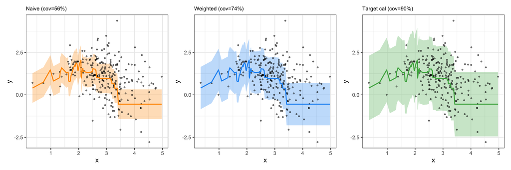

```r
ord <- order(x_test_s)
df_plot <- tibble(x = x_test_s[ord], y = y_test_s[ord], yhat = yhat_test[ord])

make_panel <- function(qh, color, title) {
  ggplot(df_plot, aes(x = x)) +
    geom_ribbon(aes(ymin = yhat - qh, ymax = yhat + qh), fill = color, alpha = 0.3) +
    geom_point(aes(y = y), size = 0.8, alpha = 0.5) +
    geom_line(aes(y = yhat), color = color, linewidth = 0.8) +
    labs(title = title, y = "y") +
    theme_bw() + theme(plot.title = element_text(size = 9))
}

make_panel(q_naive,    "#FF9800", sprintf("Naive (cov=%.0f%%)", 100*eval_cov(q_naive))) +
make_panel(q_weighted, "#2196F3", sprintf("Weighted (cov=%.0f%%)", 100*eval_cov(q_weighted))) +
make_panel(q_tgt,      "#4CAF50", sprintf("Target cal (cov=%.0f%%)", 100*eval_cov(q_tgt))) +
plot_layout(ncol = 3)
```

> **Takeaway for the project:** In the final project, `target_cal` and `target_test` are both from Medicare — they are exchangeable, so standard conformal prediction works directly. The Private-to-Medicare shift involves both label shift and covariate shift (as discussed in the calibration lecture), so weighted conformal with estimated weights would be a heuristic approximation if no labeled target data were available.

## 8 Bootstrap Confidence Intervals for Performance Metrics

### 8.1 Why Bootstrap?

Conformal prediction gives **predictive uncertainty** — prediction sets for individual outcomes. But we also need **metric uncertainty**: how reliable are our estimates of AUROC and Brier score on the target test set?

This is the **required** uncertainty deliverable for Section 2.5 of the final project: bootstrap confidence intervals for AUROC and Brier on `target_test`.

### 8.2 The Bootstrap Procedure

1. Let `target_test` have $n$ observations with predicted probabilities $\hat{p}_1, \ldots, \hat{p}_n$ and true labels $y_1, \ldots, y_n$.
2. For $b = 1, \ldots, B$ (e.g., $B = 2000$):
   - Resample $n$ observations **with replacement** from `target_test`.
   - Compute AUROC$^{(b)}$ and Brier$^{(b)}$ on the bootstrap sample.
3. The 95% bootstrap percentile CI for AUROC is $[\text{AUROC}^{(0.025)},\; \text{AUROC}^{(0.975)}]$.

```r
library(yardstick)
set.seed(274)

B <- 2000
n_test <- length(p_test)
boot_auroc <- boot_brier <- numeric(B)

for (b in seq_len(B)) {
  idx_b <- sample(n_test, replace = TRUE)
  p_b   <- p_test[idx_b]
  y_b   <- y_test[idx_b]

  boot_auroc[b] <- tryCatch(
    roc_auc_vec(y_b, p_b, event_level = "second"),
    error = function(e) NA_real_)
  boot_brier[b] <- mean((p_b - as.numeric(y_b == "Yes"))^2)
}

boot_auroc <- boot_auroc[!is.na(boot_auroc)]

auroc_point <- roc_auc_vec(y_test, p_test, event_level = "second")
brier_point <- mean((p_test - as.numeric(y_test == "Yes"))^2)

ci_auroc <- quantile(boot_auroc, c(0.025, 0.975))
ci_brier <- quantile(boot_brier, c(0.025, 0.975))

cat(sprintf("AUROC: %.3f  [95%% CI: %.3f, %.3f]\n", auroc_point, ci_auroc[1], ci_auroc[2]))
```

```
AUROC: 0.697  [95% CI: 0.650, 0.744]
```

```r
cat(sprintf("Brier: %.4f  [95%% CI: %.4f, %.4f]\n", brier_point, ci_brier[1], ci_brier[2]))
```

```
Brier: 0.1654  [95% CI: 0.1475, 0.1831]
```

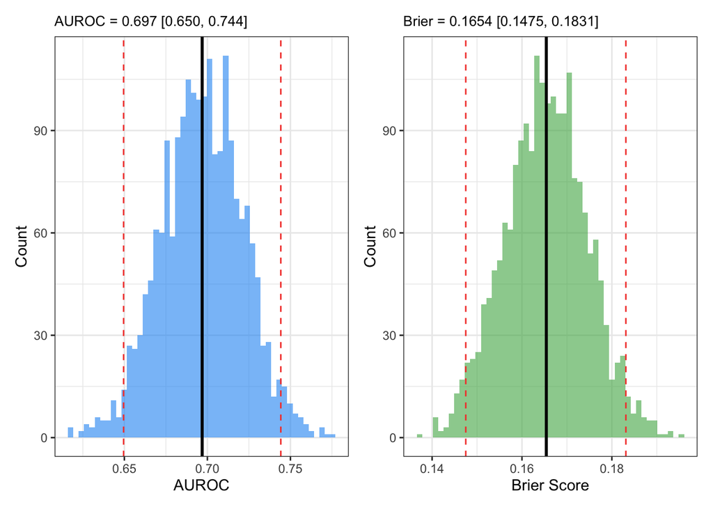

Bootstrap distributions of AUROC and Brier score. Dashed red lines show the 95% percentile confidence interval.

```r
p1 <- tibble(x = boot_auroc) %>%
  ggplot(aes(x = x)) +
  geom_histogram(bins = 50, fill = "#2196F3", alpha = 0.6) +
  geom_vline(xintercept = ci_auroc, linetype = "dashed", color = "#F44336") +
  geom_vline(xintercept = auroc_point, linewidth = 1) +
  labs(x = "AUROC", y = "Count",
       title = sprintf("AUROC = %.3f [%.3f, %.3f]", auroc_point, ci_auroc[1], ci_auroc[2])) +
  theme_bw() + theme(plot.title = element_text(size = 10))

p2 <- tibble(x = boot_brier) %>%
  ggplot(aes(x = x)) +
  geom_histogram(bins = 50, fill = "#4CAF50", alpha = 0.6) +
  geom_vline(xintercept = ci_brier, linetype = "dashed", color = "#F44336") +
  geom_vline(xintercept = brier_point, linewidth = 1) +
  labs(x = "Brier Score", y = "Count",
       title = sprintf("Brier = %.4f [%.4f, %.4f]", brier_point, ci_brier[1], ci_brier[2])) +
  theme_bw() + theme(plot.title = element_text(size = 10))

p1 + p2
```

**NotePaired bootstrap for comparing models**

When comparing raw vs. recalibrated predictions on the **same** `target_test`, use a **paired bootstrap**: resample the same indices for both models in each iteration. This preserves the correlation and gives a valid CI for the **difference** in metrics (e.g., $\Delta$AUROC = AUROC$_{\text{recal}}$ - AUROC$_{\text{raw}}$).

## 9 Summary

### 9.1 Uncertainty Quantification: A Taxonomy

| Approach | Question it answers | Assumptions | Guarantee |
| --- | --- | --- | --- |
| Calibration diagnostics | Are probabilities correct on average? | Nonparametric (binning, Loess) | Descriptive |
| Recalibration | Can we fix probabilities for a new domain? | Model structure (logistic link, isotonic) | Asymptotic |
| **Bootstrap CI** | **How variable is AUROC / Brier?** | **i.i.d. resampling** | **Asymptotic** |
| **Conformal prediction** | **What outcomes are plausible for a new observation?** | **Exchangeability** | **Finite-sample, marginal** |

### 9.2 Three Takeaways

1. **Simple:** Split conformal prediction is 3 steps — compute scores, take the $k$-th order statistic, form sets. About 15 lines of code.
2. **Rigorous:** The marginal coverage guarantee holds for any model, any distribution, any finite sample size. The only assumption is exchangeability of calibration and test data.
3. **Two kinds of uncertainty for the project:** Bootstrap CIs quantify how reliable your AUROC/Brier estimates are (metric uncertainty — **required**). Conformal prediction sets quantify how reliable individual predictions are (predictive uncertainty — **optional extension**).

## 10 Application to Final Project (Readmission)

### 10.1 Connecting to Section 2.5: Uncertainty (10 pts)

**Required:** Bootstrap confidence intervals for AUROC and Brier score on `target_test`.

**Optional extension:** Conformal prediction sets for individual patient-level predictive uncertainty.

### 10.2 Required: Bootstrap CIs

```r
B <- 2000; n_test <- nrow(target_test)
boot_auroc <- boot_brier <- numeric(B)

for (b in seq_len(B)) {
  idx <- sample(n_test, replace = TRUE)
  p_b <- p_test[idx]; y_b <- y_test[idx]
  boot_auroc[b] <- roc_auc_vec(y_b, p_b, event_level = "second")
  boot_brier[b] <- mean((p_b - as.numeric(y_b == "Yes"))^2)
}

quantile(boot_auroc, c(0.025, 0.975))  # 95% CI for AUROC
quantile(boot_brier, c(0.025, 0.975))  # 95% CI for Brier
```

### 10.3 What to Report

| Model | AUROC [95% CI] | Brier [95% CI] |
| --- | --- | --- |
| Logistic (raw) |  |  |
| Logistic (recalibrated) |  |  |
| XGBoost (raw) |  |  |
| XGBoost (recalibrated) |  |  |

### 10.4 Optional: Conformal Prediction Sets

```r
s_cal <- ifelse(y_cal == "Yes", 1 - p_cal, p_cal)
k     <- min(ceiling((1 - alpha) * (length(s_cal) + 1)), length(s_cal))
q_hat <- sort(s_cal)[k]

pred_sets <- lapply(p_test, function(p) {
  S <- c()
  if (p >= 1 - q_hat) S <- c(S, "Yes")
  if ((1 - p) >= 1 - q_hat) S <- c(S, "No")
  S
})
```

## 11 Further Reading

### 11.1 Primary

1. Angelopoulos & Bates (2023). [*A Gentle Introduction to Conformal Prediction*](https://arxiv.org/abs/2107.07511). Sections 1-3. Free PDF + [Python notebooks](https://github.com/aangelopoulos/conformal-prediction).
2. Tibshirani (2024). [*Conformal Prediction*](https://www.stat.berkeley.edu/~ryantibs/statlearn-s24/lectures/conformal.pdf). Lecture notes, UC Berkeley.

### 11.2 Supplementary

3. Tibshirani et al. (2019). [*Conformal Prediction Under Covariate Shift*](https://www.stat.cmu.edu/~ryantibs/papers/weightedcp.pdf). NeurIPS 2019.
4. Kota et al. (2023). [*Safe and reliable transport of prediction models to new healthcare settings*](https://pmc.ncbi.nlm.nih.gov/articles/PMC10760294/). *Nature Communications*.
5. Kaiser & Herzog (2025). [*A Tutorial on Distribution-Free UQ Using Conformal Prediction*](https://journals.sagepub.com/doi/10.1177/25152459251380452). R-focused tutorial with [code supplement](https://osf.io/d9w8n/).

### 11.3 Video

- [Angelopoulos & Bates ICML 2021 Tutorial](https://www.youtube.com/watch?v=nql000Lu_iE) (~30 min)
- [Candes: “How to increase certainty in predictive modeling”](https://www.youtube.com/watch?v=fQQP84yxCRs) (Stanford, 2021)